# SeqAn Usage Statistics

Svenja Mehringer

24 April 2017

This is an automatically generated report that evaluates the current SeqAn user statistics. The data is taken from the file `../logfiles/seqan.logs` preprocessed by a script `global_seqan.R`. If you want to evaluate this report on another file, please change the variable `seqan_log_file` in the script `global_seqan.R`.

## The Data

The collected infromation contains the following columns:

The column names of the collected user information.

[output not shown]

Some preprocessing details (`global_seqan.R`):

- All entries marked as clusters are removed from the data set.
- A seperate table keeps track of the amount of cluster uses.
- The date column is transform to a date-format of R.

## SeqAn

To display the general usage of Seqan, the plot shows the cumulative usage of all application summed together over the given time period.

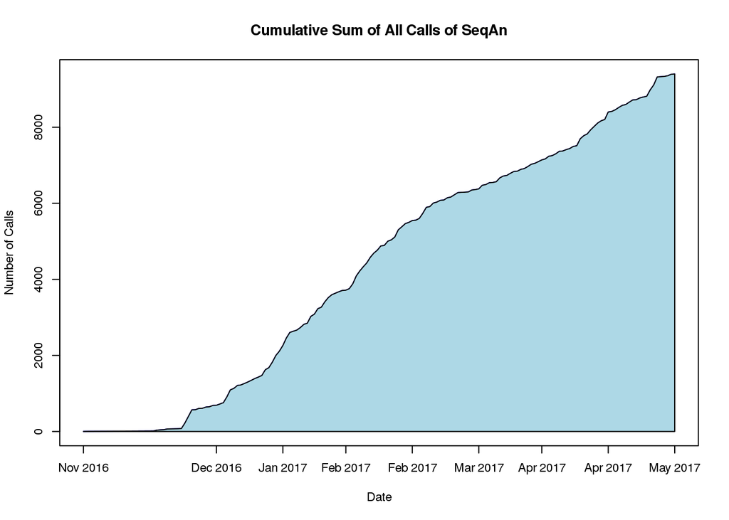

## Distribution of Countries and Cities per SeqAn Application

|  | #Countries | Country with most calls | #Cities | City with most calls |
| --- | --- | --- | --- | --- |
| razers3 | 19 | United States | 63 | Ashburn |
| yara_mapper | 10 | United States | 22 | Ashburn |
| sak | 9 | United States | 29 | Ashburn |
| mason_simulator | 8 | United States | 24 | Ashburn |
| yara_indexer | 7 | United States | 18 | Ashburn |
| seqan_tcoffee | 7 | United States | 10 | Ashburn |
| mason_variator | 7 | United States | 13 | Ashburn |
| micro_razers | 6 | United States | 8 | Ashburn |
| mason_genome | 6 | United States | 12 | Ashburn |
| stellar | 5 | United States | 14 | Ashburn |
| razers | 5 | United States | 8 | Ashburn |
| gustaf | 5 | United States | 12 | Ashburn |
| pair_align | 4 | United States | 6 | Ashburn |
| mason_materializer | 4 | United States | 12 | Ashburn |
| fiona | 4 | United States | 8 | Ashburn |
| alf | 4 | Germany | 8 | Berlin |
| tree_recon | 3 | United States | 5 | Ashburn |
| splazers | 3 | United States | 5 | Ashburn |
| seqcons2 | 3 | United States | 5 | Ashburn |
| samcat | 3 | United States | 4 | Ashburn |
| sam2matrix | 3 | United States | 4 | Ashburn |
| rabema_prepare_sam | 3 | United States | 7 | Ashburn |
| rabema_evaluate | 3 | United States | 8 | Ashburn |
| rabema_build_gold_standard | 3 | United States | 7 | Ashburn |
| mason_methylation | 3 | Germany | 8 | Berlin |
| mason_frag_sequencing | 3 | Germany | 9 | Berlin |
| gustaf_mate_joining | 3 | United States | 7 | Ashburn |
| dfi | 3 | United States | 4 | Ashburn |
| snp_store | 2 | United States | 4 | Ashburn |
| sgip | 2 | United States | 3 | Ashburn |
| roi_feature_projection | 2 | United States | 3 | Ashburn |
| mason_splicing | 2 | Germany | 5 | Berlin |
| insegt | 2 | United States | 4 | Ashburn |
| four2three | 2 | Germany | 2 | Berlin |
| fiona_illumina | 2 | United States | 2 | Ashburn |
| compute_gain | 2 | United States | 2 | Ashburn |
| casbar | 2 | United States | 3 | Ashburn |
| bisar | 2 | United States | 3 | Ashburn |
| bam2roi | 2 | United States | 3 | Ashburn |
| roi_plot_thumbnails | 1 | Germany | 1 | Berlin |
| rep_sep | 1 | Japan | 1 |  |
| razers3_quality2prob | 1 | New Zealand | 1 | Auckland |
| fx_fastq_stats | 1 | Germany | 1 | Berlin |
| fx_bam_coverage | 1 | Germany | 2 | Berlin |

## Daily and Weekly usage of SeqAn Applications

|  | Total Sum | Average per Day | Average per Week |
| --- | --- | --- | --- |
| alf | 104 | 0.6153846 | 4.3076923 |
| bam2roi | 153 | 0.9053254 | 6.3372781 |
| bisar | 198 | 1.1715976 | 8.2011834 |
| casbar | 197 | 1.1656805 | 8.1597633 |
| compute_gain | 178 | 1.0532544 | 7.3727811 |
| dfi | 196 | 1.1597633 | 8.1183432 |
| fiona | 191 | 1.1301775 | 7.9112426 |
| fiona_illumina | 146 | 0.8639053 | 6.0473373 |
| four2three | 77 | 0.4556213 | 3.1893491 |
| fx_bam_coverage | 82 | 0.4852071 | 3.3964497 |
| fx_fastq_stats | 46 | 0.2721893 | 1.9053254 |
| gustaf | 189 | 1.1183432 | 7.8284024 |
| gustaf_mate_joining | 165 | 0.9763314 | 6.8343195 |
| insegt | 195 | 1.1538462 | 8.0769231 |
| mason_frag_sequencing | 94 | 0.5562130 | 3.8934911 |
| mason_genome | 217 | 1.2840237 | 8.9881657 |
| mason_materializer | 221 | 1.3076923 | 9.1538462 |
| mason_methylation | 49 | 0.2899408 | 2.0295858 |
| mason_simulator | 328 | 1.9408284 | 13.5857988 |
| mason_splicing | 45 | 0.2662722 | 1.8639053 |
| mason_variator | 232 | 1.3727811 | 9.6094675 |
| micro_razers | 155 | 0.9171598 | 6.4201183 |
| pair_align | 152 | 0.8994083 | 6.2958580 |
| rabema_build_gold_standard | 206 | 1.2189349 | 8.5325444 |
| rabema_evaluate | 212 | 1.2544379 | 8.7810651 |
| rabema_prepare_sam | 206 | 1.2189349 | 8.5325444 |
| razers | 170 | 1.0059172 | 7.0414201 |
| razers3 | 934 | 5.5266272 | 38.6863905 |
| razers3_quality2prob | 1 | 0.0059172 | 0.0414201 |
| rep_sep | 1 | 0.0059172 | 0.0414201 |
| roi_feature_projection | 148 | 0.8757396 | 6.1301775 |
| roi_plot_thumbnails | 30 | 0.1775148 | 1.2426036 |
| sak | 247 | 1.4615385 | 10.2307692 |
| sam2matrix | 192 | 1.1360947 | 7.9526627 |
| samcat | 198 | 1.1715976 | 8.2011834 |
| seqan_tcoffee | 212 | 1.2544379 | 8.7810651 |
| seqcons2 | 121 | 0.7159763 | 5.0118343 |
| sgip | 147 | 0.8698225 | 6.0887574 |
| snp_store | 196 | 1.1597633 | 8.1183432 |
| splazers | 150 | 0.8875740 | 6.2130178 |
| stellar | 253 | 1.4970414 | 10.4792899 |
| tree_recon | 194 | 1.1479290 | 8.0355030 |
| yara_indexer | 242 | 1.4319527 | 10.0236686 |
| yara_mapper | 1027 | 6.0769231 | 42.5384615 |

## Top 10 Applications

In the following the data was aggregated by application. The first figure pictures the sum of all calls of each application, while the second shows the number of unique users. The figures differentiate between individual and cluster calls/users. The term ‘cluster calls/users’ refers to IP addresses that were previously identified as part of a cluster, but left in the dataset as a representative for the corresponding cluster.

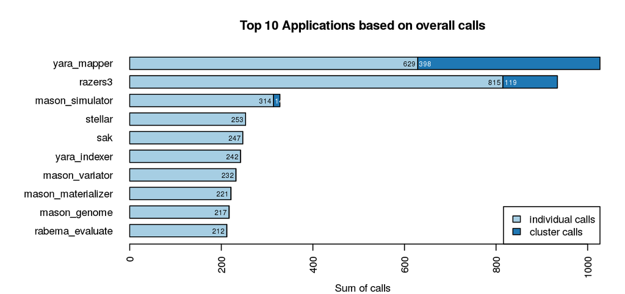

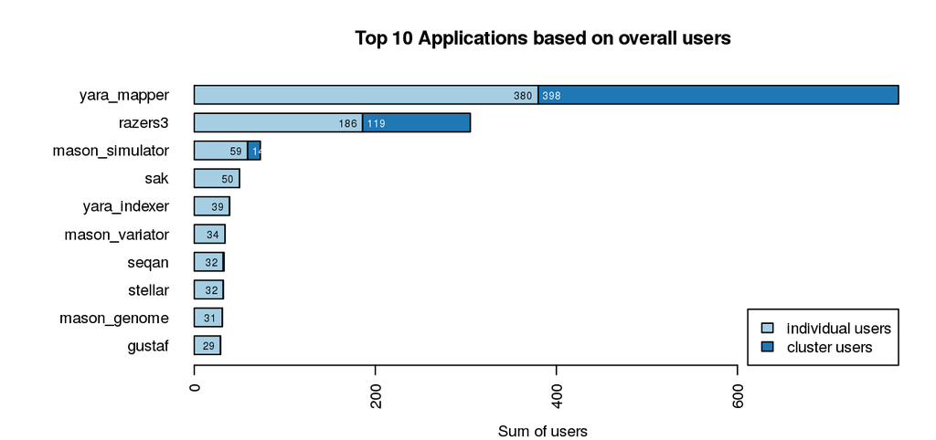

## Operating System

For an overview over the distribution of different operating systems the data was aggregated by column ‘os’. As before, the first figure pictures the sum of all calls of each operating system, while the second shows the number of unique users.

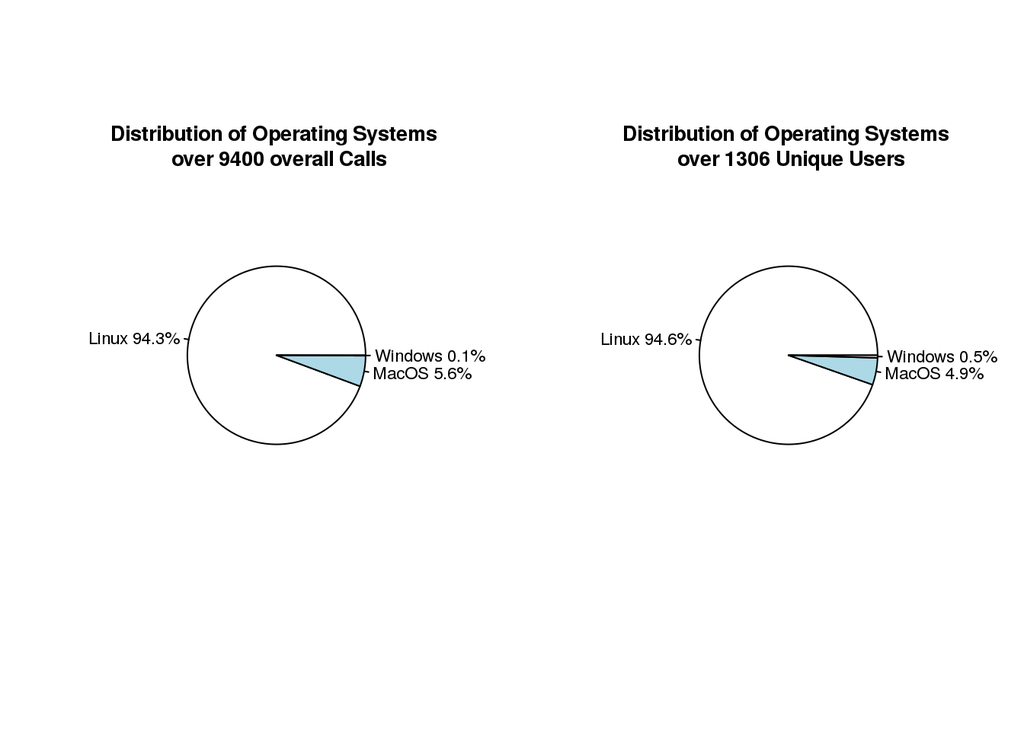

## Unique User Statistic

The bar plots on the left display the unique new users. New Unique users means that each IP Adress tracked only appears once in this statistic at the time point of it’s first occurence. The line plot on the right displays the same information as a line instead of bars. The red line on the left plot shows the cumulative sum of the new unique users.

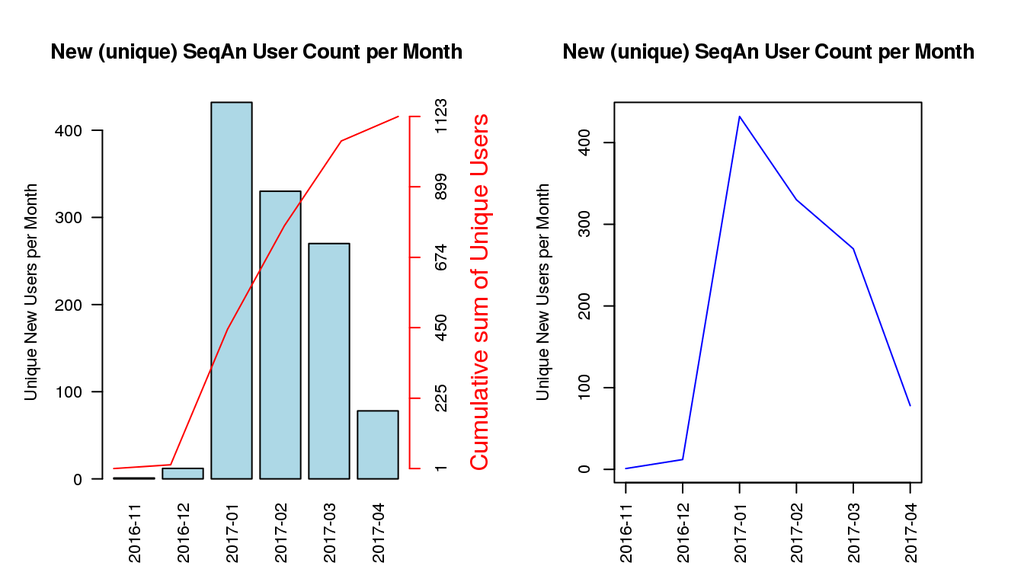

For comparison the following plots show the toal counts of usages (calls) per month, accumulated and as a line plot.

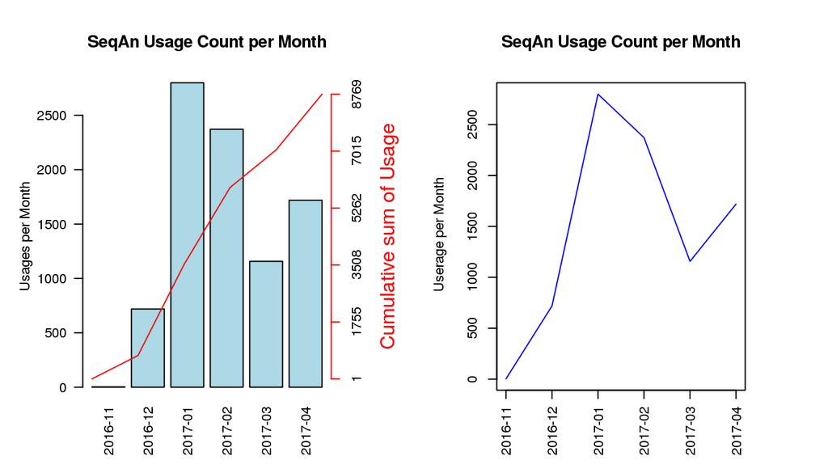